# Age-Period-Cohort Kriging

Implementation Workflow

Author

Tsai, Dai-Rong

This manual provides a practical guide to **age-period-cohort (APC) Kriging** for spatiotemporal disease mapping. Prior to implementing the method, ensure that all required packages are installed and loaded.

```r
library(stablemap)
library(dplyr)     # tabular data manipulation
library(sf)        # spatial object manipulation
library(lme4)      # mixed-effects model fitting
library(automap)   # automatic variogram fitting
```

The `{stablemap}` R package we developed provides functions to perform Kriging interpolation and generate design matrices for APC models. It’s available on GitHub:

```r
remotes::install_github("darentsai/stablemap")
```

## 1 Import the shapefile to generate centroid and grid coordinates

`{stablemap}` includes the township-level shapefile for the main island of Taiwan. We import the shapefile using `st_read()` from the [sf](https://r-spatial.github.io/sf/) package:

```r
map <- st_read(dsn = system.file("extdata", "tw_map", package = "stablemap"),
               layer = "TAIWAN_MAIN_ISLAND",
               stringsAsFactors = FALSE)
```

- Subset the study region (57 administrative units in Chiayi and Tainan)

  ```r
  map <- map |>
    select(COUNTYCODE, TOWNCODE, TOWNENG) |>
    filter(COUNTYCODE %in% c("67000","10010","10020"))
  ```

  |  | COUNTYCODE | TOWNCODE | TOWNENG | geometry |
  | --- | --- | --- | --- | --- |
  | 1 | 10010 | 10010010 | Taibao City |  |
  | 2 | 10010 | 10010130 | Zhongpu Township |  |
  | 3 | 10010 | 10010160 | Fanlu Township |  |
  | 4 | 10010 | 10010120 | Shuishang Township |  |
  | 5 | 10010 | 10010090 | Dongshi Township |  |
  | 6 | 10010 | 10010020 | Puzi City |  |
  | 7 | 10010 | 10010040 | Dalin Township |  |
  | 8 | 10010 | 10010050 | Minxiong Township |  |
  | 9 | 10010 | 10010060 | Xikou Township |  |
  | 10 | 10010 | 10010070 | Xingang Township |  |

  [output cut: 47 more lines]

- Compute the centroid coordinate for each administrative unit

  ```r
  unit_centr <- st_centroid(map)
  ```

- Create a regular grid, retaining the grid points falling within the boundary

  ```r
  grid_all <- st_make_grid(map, cellsize = 0.01, what = "centers")
  grid <- grid_all[map]
  ```

- Overview

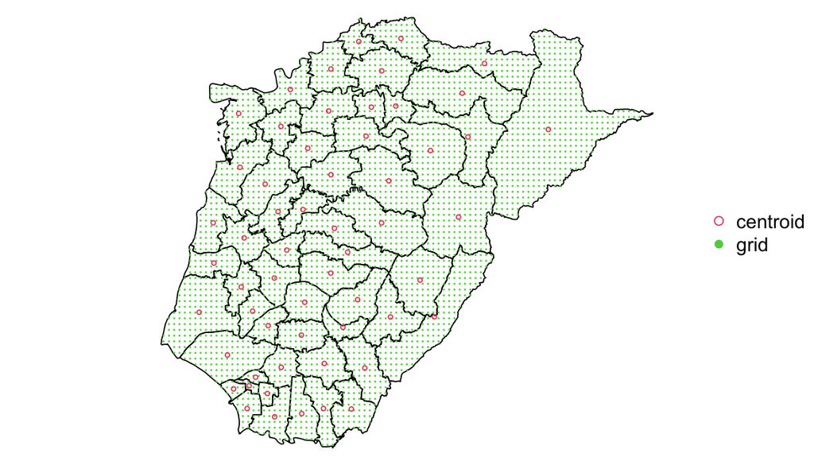

  ```r
  par(mai = c(0, 0, 0, 0))
  plot(st_geometry(map))
  points(grid, col = 3, cex = 0.1)
  points(unit_centr, col = 2, cex = 0.5)
  legend("right", legend = c("centroid", "grid"), bty = "n",
         col = c(2, 3), pch = c(1, 16))
  ```

## 2 Prepare the age-period-cohort data and design matrix

The simulated age-period data are provided in https://github.com/darentsai/apc-kriging. Here we use `apc_example_2.csv` to demonstrate how APC Kriging can be used to identify space-time disease trends. The dataset contains the observed number of cases (`CASE`) and population size (`POP`) for each combination of

- 57 administrative units
- 5 calendar periods (1995-1999, …, 2015-2019)
- 9 age groups (40-44, …, 80-84)

It’s recommended to sort the data sequentially by unit IDs (`TOWNCODE`), calendar periods (`PERIOD`), and then by age groups (`AGE`).

```r
dat <- read.csv("example/apc_example_2.csv", colClasses = c(TOWNCODE = "character")) |>
  arrange(TOWNCODE, PERIOD, AGE)
```

**Preview (first unit)**

```r
head(dat, 9)
```

|  | TOWNCODE | PERIOD | AGE | CASE | POP |
| --- | --- | --- | --- | --- | --- |
| 1 | 10010010 | 1995-1999 | 40-44 | 30 | 51078 |
| 2 | 10010010 | 1995-1999 | 45-49 | 16 | 19463 |
| 3 | 10010010 | 1995-1999 | 50-54 | 23 | 14765 |
| 4 | 10010010 | 1995-1999 | 55-59 | 252 | 202978 |
| 5 | 10010010 | 1995-1999 | 60-64 | 44 | 43208 |
| 6 | 10010010 | 1995-1999 | 65-69 | 91 | 57218 |
| 7 | 10010010 | 1995-1999 | 70-74 | 42 | 30191 |
| 8 | 10010010 | 1995-1999 | 75-79 | 80 | 41929 |
| 9 | 10010010 | 1995-1999 | 80-84 | 237 | 82528 |

**(last unit)**

```r
tail(dat, 9)
```

|  | TOWNCODE | PERIOD | AGE | CASE | POP |
| --- | --- | --- | --- | --- | --- |
| 2557 | 67000370 | 2015-2019 | 40-44 | 2 | 4982 |
| 2558 | 67000370 | 2015-2019 | 45-49 | 6 | 13891 |
| 2559 | 67000370 | 2015-2019 | 50-54 | 41 | 39854 |
| 2560 | 67000370 | 2015-2019 | 55-59 | 23 | 16752 |
| 2561 | 67000370 | 2015-2019 | 60-64 | 9 | 4146 |
| 2562 | 67000370 | 2015-2019 | 65-69 | 40 | 14870 |
| 2563 | 67000370 | 2015-2019 | 70-74 | 299 | 81337 |
| 2564 | 67000370 | 2015-2019 | 75-79 | 65 | 15793 |
| 2565 | 67000370 | 2015-2019 | 80-84 | 220 | 50240 |

- Convert age and period to numeric indices and compute the corresponding cohort index

  ```r
  dat <- dat |>
    mutate(AGE = match(AGE, unique(AGE)),
           PERIOD = match(PERIOD, unique(PERIOD)),
           COHORT = PERIOD - AGE + max(AGE))
  ```

- Construct the APC design matrix for each unit, and bind them together

  ```r
  dmat <- lapply(unique(dat$TOWNCODE), \(x) {
      datx <- subset(dat, TOWNCODE == x)
      with(datx, apc_dmat(AGE, PERIOD, COHORT))
    }) |>
    do.call(what = rbind)

  colnames(dmat) <- c("Int", "A", "C",
                      paste0("A_curv", seq_len(max(dat$AGE) - 2)),
                      paste0("P_curv", seq_len(max(dat$PERIOD) - 2)),
                      paste0("C_curv", seq_len(max(dat$COHORT) - 2)))
  ```

  Suppose there are $n_A$ age groups, $n_P$ calendar periods, and $n_C$ birth cohorts. The columns of the design matrix represent:
  - intercept
  - centered ages
  - centered cohorts
  - $n_A - 2$ age curvatures
  - $n_P - 2$ period curvatures
  - $n_C - 2$ cohort curvatures

  in that order. In this case, we obtain 7 age curvatures, 3 period curvatures, and 11 cohort curvatures.
- Combine the design matrix with unit IDs, population sizes, and case counts to construct the final data frame for model fitting

  ```r
  apc_dat <- cbind(dat[c("TOWNCODE", "CASE", "POP")], dmat)
  ```

## 3 Fit the APC Kriging model

- Fit a mixed-effects APC model with Poisson likelihood

  ```r
  apc_mod <- glmer(
    CASE ~ A + C +
      A_curv1 + A_curv2 + A_curv3 + A_curv4 + A_curv5 + A_curv6 + A_curv7 +
      P_curv1 + P_curv2 + P_curv3 +
      C_curv1 + C_curv2 + C_curv3 + C_curv4 + C_curv5 + C_curv6 +
      C_curv7 + C_curv8 + C_curv9 + C_curv10 + C_curv11 +
      (1 + A + C | TOWNCODE),
    data = apc_dat, family = "poisson", offset = log(POP),
    control = glmerControl(optimizer = "nloptwrap", calc.derivs = FALSE)
  )
  ```

- Extract the following components from the APC model:
  1. Fixed effects

     ```r
     fix_ef <- fixef(apc_mod)
     ```

  2. Random effects for intercept, age, and cohort

     ```r
     ran_ef <- ranef(apc_mod)$TOWNCODE
     colnames(ran_ef) <- c("ran_int", "ran_age", "ran_coh")
     ```

  3. Posterior variances of the random effects

     ```r
     ran_ef_var <- t(apply(attr(ran_ef, "postVar"), 3, diag))
     colnames(ran_ef_var) <- c("var_int", "var_age", "var_coh")
     ```

- Merge the three random effects and their posterior variances into the unit centroid data

  ```r
  spdat <- left_join(unit_centr,
                     data.frame(TOWNCODE = rownames(ran_ef), ran_ef, ran_ef_var),
                     by = "TOWNCODE")
  ```

- Fit variogram models for the random effects

  ```r
  vgm_int <- autofitVariogram(ran_int ~ 1, as_Spatial(spdat))$var_model
  vgm_age <- autofitVariogram(ran_age ~ 1, as_Spatial(spdat))$var_model
  vgm_coh <- autofitVariogram(ran_coh ~ 1, as_Spatial(spdat))$var_model
  ```

- Interpolate random effects to the grid using stabilized kriging

  ```r
  krige_int <- krige_sp(ran_int ~ 1, spdat, model = vgm_int, errorVar = var_int)
  krige_age <- krige_sp(ran_age ~ 1, spdat, model = vgm_age, errorVar = var_age)
  krige_coh <- krige_sp(ran_coh ~ 1, spdat, model = vgm_coh, errorVar = var_coh)

  ran_ef_krige <- cbind(predict(krige_int, grid)$var1.pred,
                        predict(krige_age, grid)$var1.pred,
                        predict(krige_coh, grid)$var1.pred)
  ```

## 4 Prediction

Prediction from the fitted model requires first generating the design matrix for the specified cells. Here, we predict all 9×13=117 age-cohort cells.

- Create the design matrix for the target age-cohort cells

  ```r
  A_curv <- apc_dat |>
    select(A, contains("A_curv")) |>
    filter(!duplicated(A))

  P_curv <- apc_dat |>
    mutate(P = A + C) |>
    select(P, contains("P_curv")) |>
    filter(!duplicated(P))

  C_curv <- apc_dat |>
    select(C, contains("C_curv")) |>
    filter(!duplicated(C))

  dmat_new <- expand.grid(Int = 1, A = A_curv$A, C = C_curv$C) |>
    mutate(P = A + C) |>
    left_join(A_curv, by = "A") |>
    left_join(P_curv, by = "P") |>
    left_join(C_curv, by = "C") |>
    arrange(A, C) |>
    select(-P)
  ```

  Note that some age-cohort cells correspond to unobserved periods, producing missing period curvatures. We can impute them with the expected value of the curvatures, namely 0.

  ```r
  dmat_new[is.na(dmat_new)] <- 0
  ```

- Add the kriged random effects to their respective fixed effects to obtain grid-level coefficients

  ```r
  grid_coef <- matrix(fix_ef, nrow = nrow(ran_ef_krige), ncol = length(fix_ef), byrow = TRUE)
  grid_coef[, 1:3] <- grid_coef[, 1:3] + ran_ef_krige
  ```

- Multiply the design matrix by the corresponding coefficients, exponentiating the result to yield predicted disease rates

  ```r
  pred <- exp(as.matrix(dmat_new) %*% t(grid_coef)) * 1e5
  ```

The final output is a 117x3769 matrix: disease rates for 117 age-cohort cells across 3,769 grid points.

## 5 Visualization

We display the predicted disease rates accompanied by the raw observed rates at the median age group (60-64 years; centered age index being 0) across 1925-1965 birth cohorts (centered cohort index from -4 to 4). Note that only cases from the 1935-1955 birth cohorts are available within this age group.

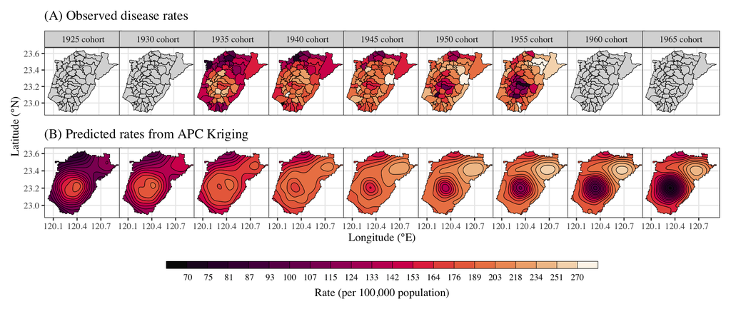

```r
library(ggplot2)
library(patchwork)

# log-scale colorbar
rate_cutpoint <- c(-Inf, round(exp(seq(log(70), log(270), length = 20))), Inf)

cohort_ind <- -4:4
predx <- pred[dmat_new$A == 0 & dmat_new$C %in% cohort_ind, ]
rownames(predx) <- cohort_ind

dat_pred <- cbind(st_coordinates(grid), t(predx)) |>
  as.data.frame() |>
  tidyr::pivot_longer(all_of(as.character(cohort_ind)),
                      names_to = "cohort", values_to = "rate",
                      names_transform = as.integer)

dat_obs <- apc_dat |>
  filter(A == 0) |>
  select(TOWNCODE, cohort = C, CASE, POP) |>
  tidyr::complete(TOWNCODE, cohort = cohort_ind) |>
  mutate(rate = (CASE / POP) * 1e5,
         level = cut(rate, rate_cutpoint)) |>
  left_join(map, by = "TOWNCODE") |>
  st_sf()

shared_config <- list(
  facet_grid(~ cohort, labeller = labeller(cohort = \(t) paste(as.integer(t)*5 + 1945, "cohort"))),
  scale_fill_discrete(name = "Rate (per 100,000 population)",
                      palette = \(n) hcl.colors(n, "Rocket"),
                      guide = guide_colorsteps(frame.colour = "black", ticks.colour = "black",
                                               frame.linewidth = 0.2, ticks.linewidth = 0.2),
                      na.value = "grey85", drop = FALSE),
  scale_x_continuous(labels = \(x) sprintf("%.1f", x), breaks = seq(120.1, 120.7, by = 0.3)),
  scale_y_continuous(labels = \(x) sprintf("%.1f", x), breaks = seq(23, 23.6, by = 0.2)),
  theme_bw(base_family = "serif")
)

p1 <- ggplot(dat_obs) +
  geom_sf(aes(fill = level), linewidth = 0.2, colour = "black") +
  shared_config +
  theme(axis.text.x = element_blank(), axis.ticks.x = element_blank()) +
  labs(title = "(A) Observed disease rates")

p2 <- ggplot(dat_pred, aes(x = X, y = Y)) +
  geom_contour_filled(aes(z = rate), breaks = rate_cutpoint,
                      linewidth = 0.2, colour = "black") +
  coord_sf(crs = st_crs(map)) +
  shared_config +
  theme(strip.background = element_blank(), strip.text = element_blank()) +
  labs(x = "Longitude (°E)", y = "Latitude (°N)",
       title = "(B) Predicted rates from APC Kriging")

(p1 / p2 + plot_layout(guides = "collect")) &
  theme(legend.position = "bottom",
        legend.title.position = "bottom",
        legend.title = element_text(hjust = 0.5),
        legend.key.width = unit(30, "mm"),
        legend.key.height = unit(2.5, "mm"),
        axis.title.y = element_text(hjust = 6),
        panel.spacing.x = unit(-1, "mm"))
```